# Customer Fraud Analysis

#### Author: Himanshi Bairagi

Feature Explanation:

distance_from_home - The distance from home where the transaction happened.

distance_from_last_transaction - The distance from last transaction happened.

ratio_to_median_purchase_price - Ratio of purchased price transaction to median purchase price.

repeat_retailer - Is the transaction happened from same retailer.

used_chip - Is the transaction through chip (credit card).

used_pin_number - Is the transaction happened by using PIN number.

online_order - Is the transaction an online order.

fraud - Is the transaction fraudulent.

## Part 1: Exploratory Data Analysis

```python
import pandas as pd
import numpy as np
import matplotlib.pyplot as plt
import seaborn as sns

cust_df = pd.read_csv('archive\card_transdata.csv')

cust_df.head()
```

|  | distance_from_home | distance_from_last_transaction | ratio_to_median_purchase_price | repeat_retailer | used_chip | used_pin_number | online_order | fraud |
| --- | --- | --- | --- | --- | --- | --- | --- | --- |
| 0 | 57.877857 | 0.311140 | 1.945940 | 1.0 | 1.0 | 0.0 | 0.0 | 0.0 |
| 1 | 10.829943 | 0.175592 | 1.294219 | 1.0 | 0.0 | 0.0 | 0.0 | 0.0 |
| 2 | 5.091079 | 0.805153 | 0.427715 | 1.0 | 0.0 | 0.0 | 1.0 | 0.0 |
| 3 | 2.247564 | 5.600044 | 0.362663 | 1.0 | 1.0 | 0.0 | 1.0 | 0.0 |
| 4 | 44.190936 | 0.566486 | 2.222767 | 1.0 | 1.0 | 0.0 | 1.0 | 0.0 |

```python
cust_df.info()
```

```
<class 'pandas.core.frame.DataFrame'>
RangeIndex: 1000000 entries, 0 to 999999
Data columns (total 8 columns):
 #   Column                          Non-Null Count    Dtype
---  ------                          --------------    -----
 0   distance_from_home              1000000 non-null  float64
 1   distance_from_last_transaction  1000000 non-null  float64
 2   ratio_to_median_purchase_price  1000000 non-null  float64
 3   repeat_retailer                 1000000 non-null  float64
 4   used_chip                       1000000 non-null  float64
 5   used_pin_number                 1000000 non-null  float64
 6   online_order                    1000000 non-null  float64
 7   fraud                           1000000 non-null  float64
dtypes: float64(8)
memory usage: 61.0 MB
```

```python
cust_df.describe()
```

|  | distance_from_home | distance_from_last_transaction | ratio_to_median_purchase_price | repeat_retailer | used_chip | used_pin_number | online_order | fraud |
| --- | --- | --- | --- | --- | --- | --- | --- | --- |
| count | 1000000.000000 | 1000000.000000 | 1000000.000000 | 1000000.000000 | 1000000.000000 | 1000000.000000 | 1000000.000000 | 1000000.000000 |
| mean | 26.628792 | 5.036519 | 1.824182 | 0.881536 | 0.350399 | 0.100608 | 0.650552 | 0.087403 |
| std | 65.390784 | 25.843093 | 2.799589 | 0.323157 | 0.477095 | 0.300809 | 0.476796 | 0.282425 |
| min | 0.004874 | 0.000118 | 0.004399 | 0.000000 | 0.000000 | 0.000000 | 0.000000 | 0.000000 |
| 25% | 3.878008 | 0.296671 | 0.475673 | 1.000000 | 0.000000 | 0.000000 | 0.000000 | 0.000000 |
| 50% | 9.967760 | 0.998650 | 0.997717 | 1.000000 | 0.000000 | 0.000000 | 1.000000 | 0.000000 |
| 75% | 25.743985 | 3.355748 | 2.096370 | 1.000000 | 1.000000 | 0.000000 | 1.000000 | 0.000000 |
| max | 10632.723672 | 11851.104565 | 267.802942 | 1.000000 | 1.000000 | 1.000000 | 1.000000 | 1.000000 |

```python
# identify if the data has any null values
print(cust_df.isnull().sum())
```

```
distance_from_home                0
distance_from_last_transaction    0
ratio_to_median_purchase_price    0
repeat_retailer                   0
used_chip                         0
used_pin_number                   0
online_order                      0
fraud                             0
dtype: int64
```

### Number of fraudulant and non-fraudulant transactions.

```
Shape of Fraudulant transactions: (87403, 8)
Shape of Non-Fraudulant transactions: (912597, 8)
```

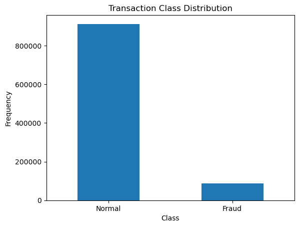

```python
fraud = cust_df[cust_df['fraud']==1]
normal = cust_df[cust_df['fraud']==0]

print(f"Shape of Fraudulant transactions: {fraud.shape}")
print(f"Shape of Non-Fraudulant transactions: {normal.shape}")

LABELS = ["Normal", "Fraud"]

# plot counts of fraudulant and non-fraudulant transactions
count_classes = pd.value_counts(cust_df['fraud'], sort = True)
count_classes.plot(kind = 'bar', rot=0)
plt.title("Transaction Class Distribution")
plt.xticks(range(2), LABELS)
plt.xlabel("Class")
plt.ylabel("Frequency");
```

### How different is the ratio to median purchase price in different transaction classes?

```python
pd.concat([fraud.ratio_to_median_purchase_price.describe(), normal.ratio_to_median_purchase_price.describe()], axis=1)
```

|  | ratio_to_median_purchase_price | ratio_to_median_purchase_price |
| --- | --- | --- |
| count | 87403.000000 | 912597.000000 |
| mean | 6.006323 | 1.423642 |
| std | 5.564320 | 1.946152 |
| min | 0.011966 | 0.004399 |
| 25% | 3.500270 | 0.449768 |
| 50% | 5.071294 | 0.913950 |
| 75% | 7.331222 | 1.788918 |
| max | 266.689692 | 267.802942 |

### Do fraudulant transactions occur futher away from the home of the customer?

```python
pd.concat([fraud.distance_from_home.describe(), normal.distance_from_home.describe()], axis=1)
```

|  | distance_from_home | distance_from_home |
| --- | --- | --- |
| count | 87403.000000 | 912597.000000 |
| mean | 66.261876 | 22.832976 |
| std | 134.391608 | 52.828655 |
| min | 0.025847 | 0.004874 |
| 25% | 4.585729 | 3.828942 |
| 50% | 15.454219 | 9.673847 |
| 75% | 101.110104 | 24.158057 |
| max | 10632.723672 | 8777.136420 |

### Is there a significant difference in the distance from the place of last trasaction for fraudulant transactions?

```python
pd.concat([fraud.distance_from_last_transaction.describe(), normal.distance_from_last_transaction.describe()], axis=1)
```

|  | distance_from_last_transaction | distance_from_last_transaction |
| --- | --- | --- |
| count | 87403.000000 | 912597.000000 |
| mean | 12.712185 | 4.301391 |
| std | 47.997697 | 22.472359 |
| min | 0.000407 | 0.000118 |
| 25% | 0.328199 | 0.293859 |
| 50% | 1.157631 | 0.985074 |
| 75% | 4.598504 | 3.268578 |
| max | 2160.499922 | 11851.104565 |

### Do fraudulant transactions happen at more distinct locations?

```python
pd.concat([fraud.repeat_retailer.describe(), normal.repeat_retailer.describe()], axis=1)
```

|  | repeat_retailer | repeat_retailer |
| --- | --- | --- |
| count | 87403.000000 | 912597.000000 |
| mean | 0.880119 | 0.881672 |
| std | 0.324825 | 0.322997 |
| min | 0.000000 | 0.000000 |
| 25% | 1.000000 | 1.000000 |
| 50% | 1.000000 | 1.000000 |
| 75% | 1.000000 | 1.000000 |
| max | 1.000000 | 1.000000 |

### Is there a difference in the authentication method across transaction classes?

```python
pd.concat([fraud.used_chip.describe(), normal.used_chip.describe()], axis=1)
```

|  | used_chip | used_chip |
| --- | --- | --- |
| count | 87403.000000 | 912597.000000 |
| mean | 0.256399 | 0.359402 |
| std | 0.436647 | 0.479825 |
| min | 0.000000 | 0.000000 |
| 25% | 0.000000 | 0.000000 |
| 50% | 0.000000 | 0.000000 |
| 75% | 1.000000 | 1.000000 |
| max | 1.000000 | 1.000000 |

```python
pd.concat([fraud.used_pin_number.describe(), normal.used_pin_number.describe()], axis=1)
```

|  | used_pin_number | used_pin_number |
| --- | --- | --- |
| count | 87403.000000 | 912597.000000 |
| mean | 0.003123 | 0.109944 |
| std | 0.055801 | 0.312821 |
| min | 0.000000 | 0.000000 |
| 25% | 0.000000 | 0.000000 |
| 50% | 0.000000 | 0.000000 |
| 75% | 0.000000 | 0.000000 |
| max | 1.000000 | 1.000000 |

### Are online transactions more prone to frauds?

```python
pd.concat([fraud.online_order.describe(), normal.online_order.describe()], axis=1)
```

|  | online_order | online_order |
| --- | --- | --- |
| count | 87403.000000 | 912597.000000 |
| mean | 0.946318 | 0.622225 |
| std | 0.225391 | 0.484831 |
| min | 0.000000 | 0.000000 |
| 25% | 1.000000 | 0.000000 |
| 50% | 1.000000 | 1.000000 |
| 75% | 1.000000 | 1.000000 |
| max | 1.000000 | 1.000000 |

## Part 2: Data Analysis

```python
np.random.seed(123)

fraud_samp = fraud.sample(50000)
normal_samp = normal.sample(50000)

fraud_samp['fraud'] = 1
normal_samp['fraud'] = 0

data_samp = pd.concat([fraud_samp, normal_samp], ignore_index=True)

data_samp.shape
```

```
(100000, 8)
```

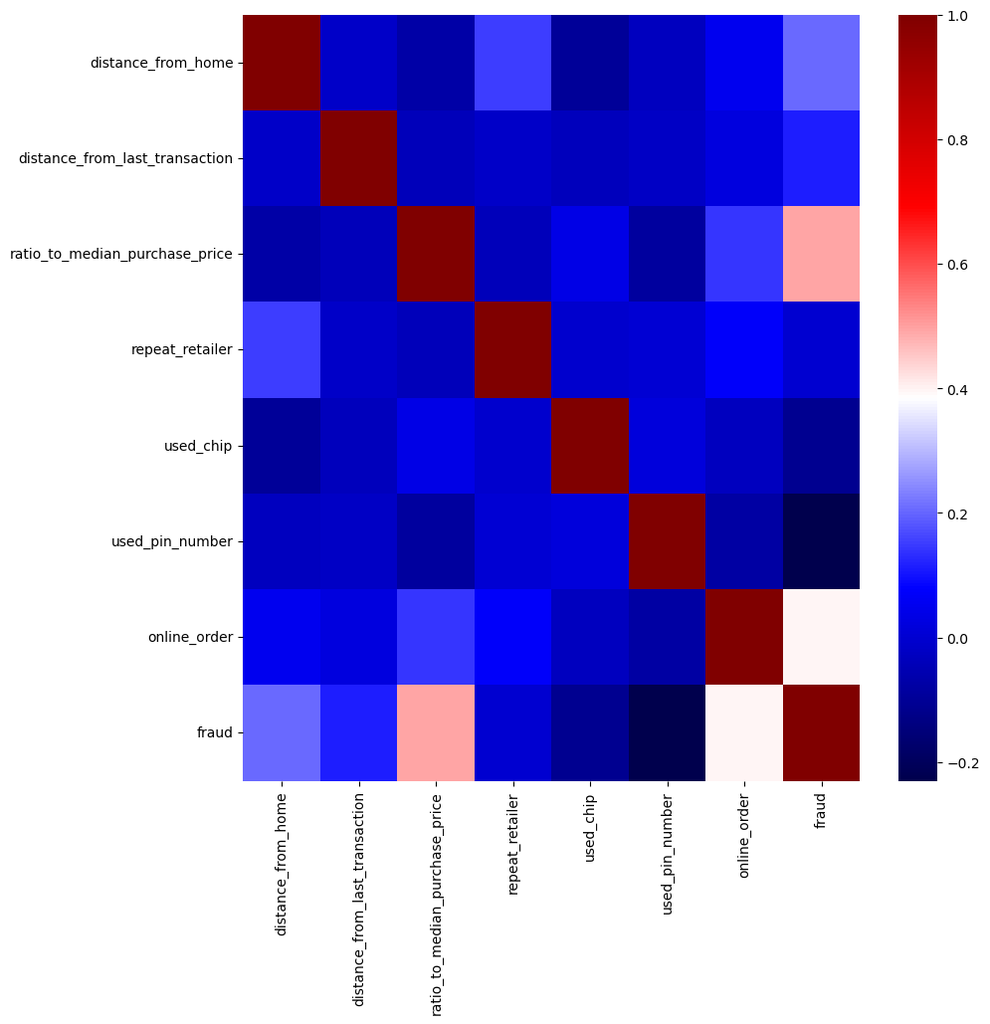

```python
# heatmap to find any high correlations

plt.figure(figsize=(10,10))
sns.heatmap(data=data_samp.corr(), cmap="seismic")
plt.show();
```

```python
data_samp.corr()
```

|  | distance_from_home | distance_from_last_transaction | ratio_to_median_purchase_price | repeat_retailer | used_chip | used_pin_number | online_order | fraud |
| --- | --- | --- | --- | --- | --- | --- | --- | --- |
| distance_from_home | 1.000000 | -0.015464 | -0.074788 | 0.150365 | -0.098006 | -0.032278 | 0.052618 | 0.203783 |
| distance_from_last_transaction | -0.015464 | 1.000000 | -0.037834 | -0.014546 | -0.034420 | -0.019685 | 0.021938 | 0.114463 |
| ratio_to_median_purchase_price | -0.074788 | -0.037834 | 1.000000 | -0.038353 | 0.035743 | -0.089682 | 0.141989 | 0.491981 |
| repeat_retailer | 0.150365 | -0.014546 | -0.038353 | 1.000000 | -0.007775 | 0.001360 | 0.070107 | -0.001172 |
| used_chip | -0.098006 | -0.034420 | 0.035743 | -0.007775 | 1.000000 | 0.018976 | -0.028834 | -0.113728 |
| used_pin_number | -0.032278 | -0.019685 | -0.089682 | 0.001360 | 0.018976 | 1.000000 | -0.078082 | -0.229947 |
| online_order | 0.052618 | 0.021938 | 0.141989 | 0.070107 | -0.028834 | -0.078082 | 1.000000 | 0.396553 |
| fraud | 0.203783 | 0.114463 | 0.491981 | -0.001172 | -0.113728 | -0.229947 | 0.396553 | 1.000000 |

Highest Co-orelation of fradulant transaction is with:

ratio_to_median_purchase_price (0.49)

online_order (0.40)  
This indicates transactions significantly higher than median purchase price and online transactions are more susceptible to fradulant activities.

```python
data_samp.head()
```

|  | distance_from_home | distance_from_last_transaction | ratio_to_median_purchase_price | repeat_retailer | used_chip | used_pin_number | online_order | fraud |
| --- | --- | --- | --- | --- | --- | --- | --- | --- |
| 0 | 3.552233 | 0.437685 | 33.188656 | 1.0 | 1.0 | 0.0 | 1.0 | 1 |
| 1 | 218.692265 | 0.133700 | 0.180273 | 1.0 | 0.0 | 0.0 | 1.0 | 1 |
| 2 | 1.838317 | 3.970778 | 7.382074 | 0.0 | 1.0 | 0.0 | 1.0 | 1 |
| 3 | 3.489291 | 0.854527 | 4.848553 | 1.0 | 1.0 | 0.0 | 1.0 | 1 |
| 4 | 7.009227 | 0.512246 | 5.509998 | 1.0 | 1.0 | 0.0 | 1.0 | 1 |

```python
from sklearn.model_selection import train_test_split
from sklearn.preprocessing import StandardScaler

scalar = StandardScaler()

X = cust_df.drop('fraud', axis=1)
y = cust_df.fraud

X_train_v, X_test, y_train_v, y_test = train_test_split(X, y,
                                                    test_size=0.3, random_state=10)
X_train, X_validate, y_train, y_validate = train_test_split(X_train_v, y_train_v,
                                                            test_size=0.2, random_state=10)

X_train = scalar.fit_transform(X_train)
X_validate = scalar.transform(X_validate)
X_test = scalar.transform(X_test)

w_p = y_train.value_counts()[0] / len(y_train)
w_n = y_train.value_counts()[1] / len(y_train)

print(f"Fraudulant transaction weight: {w_n}")
print(f"Non-Fraudulant transaction weight: {w_p}")
```

```
Fraudulant transaction weight: 0.08727321428571429
Non-Fraudulant transaction weight: 0.9127267857142857
```

```python
print(f"TRAINING: X_train: {X_train.shape}, y_train: {y_train.shape}\n{'_'*55}\n")
print(f"VALIDATION: X_validate: {X_validate.shape}, y_validate: {y_validate.shape}\n{'_'*50}\n")
print(f"TESTING: X_test: {X_test.shape}, y_test: {y_test.shape}")
```

```
TRAINING: X_train: (560000, 7), y_train: (560000,)
_______________________________________________________

VALIDATION: X_validate: (140000, 7), y_validate: (140000,)
__________________________________________________

TESTING: X_test: (300000, 7), y_test: (300000,)
```

```python
from sklearn.metrics import accuracy_score, confusion_matrix, classification_report, f1_score

def print_score(label, prediction, train=True):
    if train:
        clf_report = pd.DataFrame(classification_report(label, prediction, output_dict=True))
        print("Train Result:\n================================================")
        print(f"Accuracy Score: {accuracy_score(label, prediction) * 100:.2f}%")
        print("_______________________________________________")
        print(f"Classification Report:\n{clf_report}")
        print("_______________________________________________")
        print(f"Confusion Matrix: \n {confusion_matrix(y_train, prediction)}\n")

    elif train==False:
        clf_report = pd.DataFrame(classification_report(label, prediction, output_dict=True))
        print("Test Result:\n================================================")
        print(f"Accuracy Score: {accuracy_score(label, prediction) * 100:.2f}%")
        print("_______________________________________________")
        print(f"Classification Report:\n{clf_report}")
        print("_______________________________________________")
        print(f"Confusion Matrix: \n {confusion_matrix(label, prediction)}\n")
```

## Model Building

### 1. Artificial Neural Networks (ANNs)

```python
from tensorflow import keras

model = keras.Sequential([
    keras.layers.Dense(256, activation='relu', input_shape=(X_train.shape[-1],)),
    keras.layers.BatchNormalization(),
    keras.layers.Dropout(0.3),
    keras.layers.Dense(256, activation='relu'),
    keras.layers.BatchNormalization(),
    keras.layers.Dropout(0.3),
    keras.layers.Dense(256, activation='relu'),
    keras.layers.BatchNormalization(),
    keras.layers.Dropout(0.3),
    keras.layers.Dense(1, activation='sigmoid'),
])
METRICS = [
#     keras.metrics.Accuracy(name='accuracy'),
    keras.metrics.FalseNegatives(name='fn'),
    keras.metrics.FalsePositives(name='fp'),
    keras.metrics.TrueNegatives(name='tn'),
    keras.metrics.TruePositives(name='tp'),
    keras.metrics.Precision(name='precision'),
    keras.metrics.Recall(name='recall')
]

model.compile(optimizer=keras.optimizers.Adam(1e-4), loss='binary_crossentropy', metrics=METRICS)

callbacks = [keras.callbacks.ModelCheckpoint('fraud_model_at_epoch_{epoch}.h5')]
class_weight = {0:w_p, 1:w_n}

r = model.fit(
    X_train, y_train,
    validation_data=(X_validate, y_validate),
    batch_size=2048,
    epochs=300,
#     class_weight=class_weight,
    callbacks=callbacks,
)
score = model.evaluate(X_test, y_test)
print(score)
```

[output not shown]

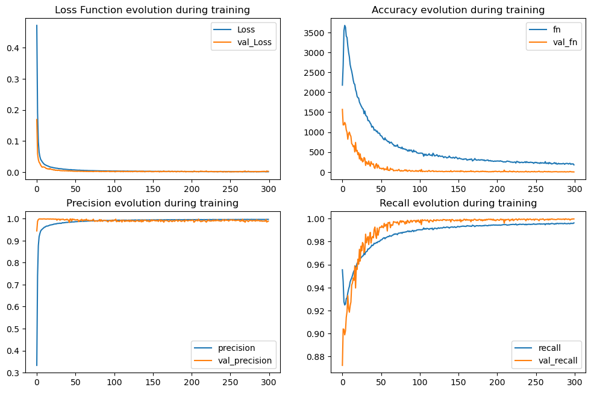

```python
plt.figure(figsize=(12, 16))

plt.subplot(4, 2, 1)
plt.plot(r.history['loss'], label='Loss')
plt.plot(r.history['val_loss'], label='val_Loss')
plt.title('Loss Function evolution during training')
plt.legend()

plt.subplot(4, 2, 2)
plt.plot(r.history['fn'], label='fn')
plt.plot(r.history['val_fn'], label='val_fn')
plt.title('Accuracy evolution during training')
plt.legend()

plt.subplot(4, 2, 3)
plt.plot(r.history['precision'], label='precision')
plt.plot(r.history['val_precision'], label='val_precision')
plt.title('Precision evolution during training')
plt.legend()

plt.subplot(4, 2, 4)
plt.plot(r.history['recall'], label='recall')
plt.plot(r.history['val_recall'], label='val_recall')
plt.title('Recall evolution during training')
plt.legend()
```

```python
y_train_pred = model.predict(X_train)
y_test_pred = model.predict(X_test)

print_score(y_train, y_train_pred.round(), train=True)
print_score(y_test, y_test_pred.round(), train=False)

scores_dict = {
    'ANNs': {
        'Train': f1_score(y_train, y_train_pred.round()),
        'Test': f1_score(y_test, y_test_pred.round()),
    },
}
```

```
Train Result:
================================================
Accuracy Score: 99.89%
_______________________________________________
Classification Report:
                     0.0           1.0  accuracy      macro avg   weighted avg
precision       0.999984      0.987990  0.998925       0.993987       0.998938
recall          0.998838      0.999836  0.998925       0.999337       0.998925
f1-score        0.999411      0.993878  0.998925       0.996644       0.998928
support    511127.000000  48873.000000  0.998925  560000.000000  560000.000000
_______________________________________________
Confusion Matrix:
 [[510533    594]
 [     8  48865]]

Test Result:
================================================
Accuracy Score: 99.88%
_______________________________________________
Classification Report:
                     0.0           1.0  accuracy      macro avg   weighted avg
precision       0.999963      0.986910  0.998807       0.993437       0.998821
recall          0.998729      0.999619  0.998807       0.999174       0.998807
f1-score        0.999346      0.993224  0.998807       0.996285       0.998810
support    273752.000000  26248.000000  0.998807  300000.000000  300000.000000
_______________________________________________
Confusion Matrix:
 [[273404    348]
 [    10  26238]]
```

### 2. XG Boost

```python
pip install xgboost;
```

```python
from xgboost import XGBClassifier

xgb_clf = XGBClassifier()
xgb_clf.fit(X_train, y_train, eval_metric='aucpr')

y_train_pred = xgb_clf.predict(X_train)
y_test_pred = xgb_clf.predict(X_test)

print_score(y_train, y_train_pred, train=True)
print_score(y_test, y_test_pred, train=False)

scores_dict['XGBoost'] = {
        'Train': f1_score(y_train,y_train_pred),
        'Test': f1_score(y_test, y_test_pred),
}
```

```
Train Result:
================================================
Accuracy Score: 100.00%
_______________________________________________
Classification Report:
                0.0      1.0  accuracy  macro avg  weighted avg
precision       1.0      1.0       1.0        1.0           1.0
recall          1.0      1.0       1.0        1.0           1.0
f1-score        1.0      1.0       1.0        1.0           1.0
support    511127.0  48873.0       1.0   560000.0      560000.0
_______________________________________________
Confusion Matrix:
 [[511127      0]
 [     0  48873]]

Test Result:
================================================
Accuracy Score: 100.00%
_______________________________________________
Classification Report:
                     0.0           1.0  accuracy      macro avg   weighted avg
precision       0.999989      0.999962  0.999987       0.999975       0.999987
recall          0.999996      0.999886  0.999987       0.999941       0.999987
f1-score        0.999993      0.999924  0.999987       0.999958       0.999987
support    273752.000000  26248.000000  0.999987  300000.000000  300000.000000
_______________________________________________
Confusion Matrix:
 [[273751      1]
 [     3  26245]]
```

### 3. Random Forest

```python
from sklearn.ensemble import RandomForestClassifier

rf_clf = RandomForestClassifier(n_estimators=100, oob_score=False)
rf_clf.fit(X_train, y_train)

y_train_pred = rf_clf.predict(X_train)
y_test_pred = rf_clf.predict(X_test)

print_score(y_train, y_train_pred, train=True)
print_score(y_test, y_test_pred, train=False)

scores_dict['Random Forest'] = {
        'Train': f1_score(y_train,y_train_pred),
        'Test': f1_score(y_test, y_test_pred),
}
```

```
Train Result:
================================================
Accuracy Score: 100.00%
_______________________________________________
Classification Report:
                0.0      1.0  accuracy  macro avg  weighted avg
precision       1.0      1.0       1.0        1.0           1.0
recall          1.0      1.0       1.0        1.0           1.0
f1-score        1.0      1.0       1.0        1.0           1.0
support    511127.0  48873.0       1.0   560000.0      560000.0
_______________________________________________
Confusion Matrix:
 [[511127      0]
 [     0  48873]]

Test Result:
================================================
Accuracy Score: 100.00%
_______________________________________________
Classification Report:
                     0.0           1.0  accuracy      macro avg   weighted avg
precision       0.999996      1.000000  0.999997       0.999998       0.999997
recall          1.000000      0.999962  0.999997       0.999981       0.999997
f1-score        0.999998      0.999981  0.999997       0.999990       0.999997
support    273752.000000  26248.000000  0.999997  300000.000000  300000.000000
_______________________________________________
Confusion Matrix:
 [[273752      0]
 [     1  26247]]
```

### 4. CatBoost

```python
pip install catboost;
```

```python
from catboost import CatBoostClassifier

cb_clf = CatBoostClassifier()
cb_clf.fit(X_train, y_train)
y_train_pred = cb_clf.predict(X_train)
y_test_pred = cb_clf.predict(X_test)
```

```python
print_score(y_train, y_train_pred, train=True)
print_score(y_test, y_test_pred, train=False)

scores_dict['CatBoost'] = {
        'Train': f1_score(y_train,y_train_pred),
        'Test': f1_score(y_test, y_test_pred),
}
```

```
Train Result:
================================================
Accuracy Score: 99.84%
_______________________________________________
Classification Report:
                     0.0           1.0  accuracy      macro avg   weighted avg
precision       0.999274      0.989857   0.99845       0.994565       0.998452
recall          0.999028      0.992409   0.99845       0.995718       0.998450
f1-score        0.999151      0.991131   0.99845       0.995141       0.998451
support    511127.000000  48873.000000   0.99845  560000.000000  560000.000000
_______________________________________________
Confusion Matrix:
 [[510630    497]
 [   371  48502]]

Test Result:
================================================
Accuracy Score: 99.80%
_______________________________________________
Classification Report:
                     0.0           1.0  accuracy      macro avg   weighted avg
precision       0.999028      0.987083   0.99798       0.993056       0.997983
recall          0.998758      0.989866   0.99798       0.994312       0.997980
f1-score        0.998893      0.988473   0.99798       0.993683       0.997981
support    273752.000000  26248.000000   0.99798  300000.000000  300000.000000
_______________________________________________
Confusion Matrix:
 [[273412    340]
 [   266  25982]]
```

### 5. LigthGBM

```python
pip install lightgbm;
```

```python
from lightgbm import LGBMClassifier

lgbm_clf = LGBMClassifier()
lgbm_clf.fit(X_train, y_train, eval_metric='aucpr')

y_train_pred = lgbm_clf.predict(X_train)
y_test_pred = lgbm_clf.predict(X_test)

print_score(y_train, y_train_pred, train=True)
print_score(y_test, y_test_pred, train=False)

scores_dict['LigthGBM'] = {
        'Train': f1_score(y_train,y_train_pred),
        'Test': f1_score(y_test, y_test_pred),
}
```

[output not shown]

### Model Comparison

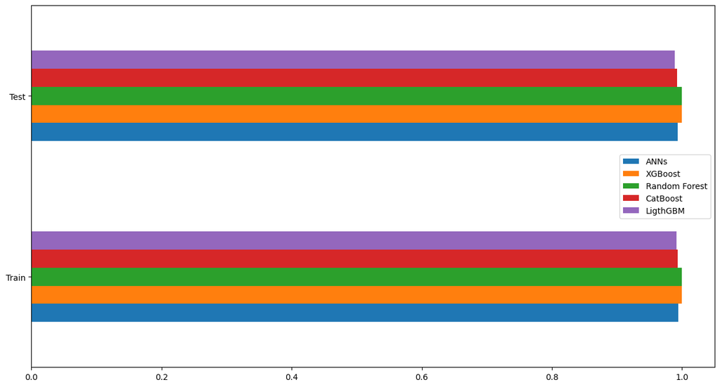

```python
scores_df = pd.DataFrame(scores_dict)

scores_df.plot(kind='barh', figsize=(15, 8))
```

### Conclusion

Random Forest and XGBoost performs the best compared to other models with an test set accuracy of almost 100%